# Ex17 GMD

PIE2

Tardor 2019-2020

#### Per veure si afegir edulcorant millora l’engreix de garrins s’ha fet una experiència en la que s’ha mesurat el guany mig diari, GMD, de garrins en les mateixes condicions però afegint edulcorant. S’han provat les 5 dosis: D00, D08, D15, D20 i D30, incloent la dosi D00 que de fet és la dieta sense edulcorant, i cada dieta s’ha provat en 5 garrins.

Els resultats experimentals obtinguts són al fitxer “gmd.csv”.

```r
#setwd("...")
#options(contrasts = c("contr.sum", "contr.treatment"))
library(car)
library(emmeans)
library(tables)
library(RcmdrMisc)
dd<-read.csv2("../data/gmd.csv")
head(dd)
```

```
##   DOSI    GMD   IC
## 1  D00 200.42 2.10
## 2  D00 190.00 2.19
## 3  D00 199.33 2.15
## 4  D00 191.00 2.10
## 5  D00 201.00 2.05
## 6  D08 210.67 2.05
```

```r
#Descriptiva
print(tabular(DOSI~GMD*((Dades=1)+(Mitjana=mean)+(Desv.Tipus=sd)),dd),justification="r")
```

```
##
##         GMD
##  DOSI Dades Mitjana Desv.Tipus
##   D00     5   196.3      5.385
##   D08     5   200.2     11.337
##   D15     5   224.2      7.564
##   D20     5   231.1      9.584
##   D30     5   231.0      9.727
```

```r
print(tabular(DOSI~GMD*((n=1)+mean+sd),dd),justification="r")
```

```
##
##       GMD
##  DOSI   n  mean     sd
##   D00   5 196.3  5.385
##   D08   5 200.2 11.337
##   D15   5 224.2  7.564
##   D20   5 231.1  9.584
##   D30   5 231.0  9.727
```

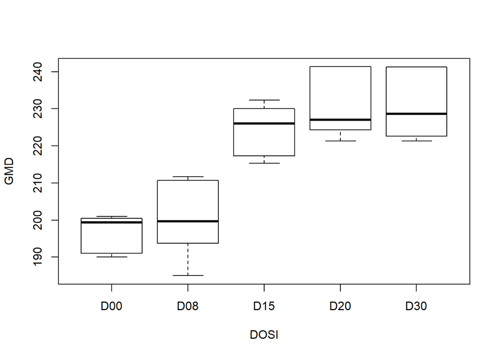

```r
scatterplot(GMD~DOSI,dd)
```

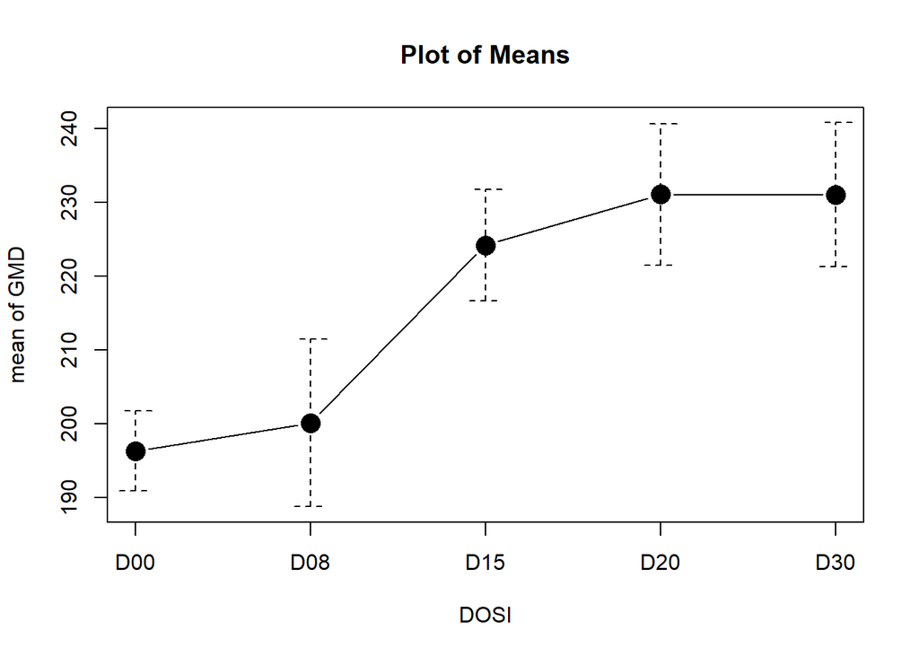

```r
with(dd,plotMeans(GMD,DOSI,error.bars = "sd"))
```

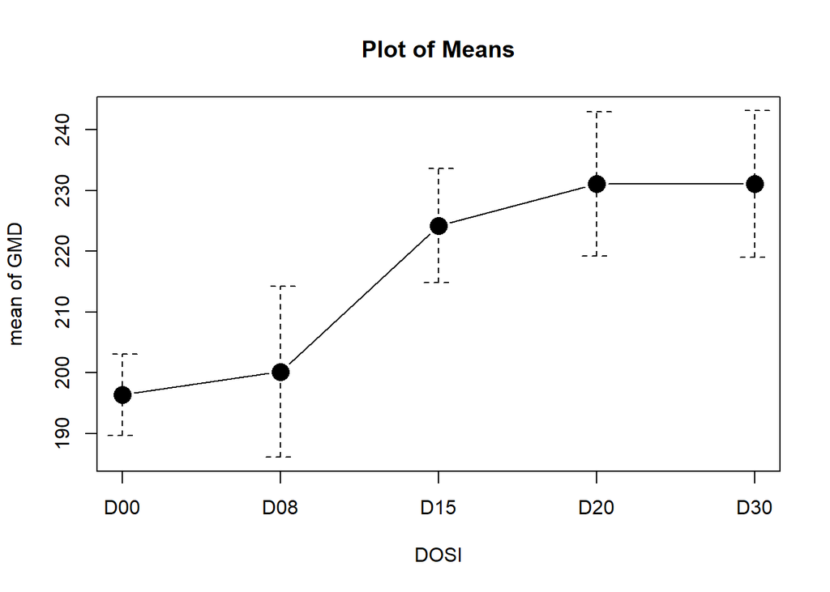

```r
with(dd,plotMeans(GMD,DOSI,error.bars = "conf.int",level=0.95))
```

```r
#==============================================================================
```

Tractant la dosis com els nivells d’un factor i $\alpha=0.05$, calculeu:

**a)** Les matrius dels següents models lineals:

**i.** $y_{ij}=\mu_{i}+\varepsilon_{ij}=\beta_{i}+\varepsilon_{ij}$

```r
x1<-diag(5)
rownames(x1)<-paste0("mu",1:5)
colnames(x1)<-paste0("beta",1:5)
print(x1)
```

```
##     beta1 beta2 beta3 beta4 beta5
## mu1     1     0     0     0     0
## mu2     0     1     0     0     0
## mu3     0     0     1     0     0
## mu4     0     0     0     1     0
## mu5     0     0     0     0     1
```

**ii.** $y_{ij}=\mu_{i}+\varepsilon_{ij}=\mu+\beta_{i}+\varepsilon_{ij}$ amb $\sum_{i=1}^{k}\beta_{i}=0$

```r
x2<-cbind(1,contrasts(C(dd$DOSI,sum)))
rownames(x2)<-paste0("mu",1:5)
colnames(x2)<-c("Int.=mu",paste0("beta",1:4))
print(x2)
```

```
##     Int.=mu beta1 beta2 beta3 beta4
## mu1       1     1     0     0     0
## mu2       1     0     1     0     0
## mu3       1     0     0     1     0
## mu4       1     0     0     0     1
## mu5       1    -1    -1    -1    -1
```

**iii.** $y_{ij}=\mu_{i}+\varepsilon_{ij}=\mu+\beta_{i}+\varepsilon_{ij}$ amb $\beta_{1}=0$

```r
x3<-cbind(1,contrasts(C(dd$DOSI,treatment)))
rownames(x3)<-paste0("mu",1:5)
colnames(x3)<-c("Int.=mu1",paste0("beta",2:5))
print(x3)
```

```
##     Int.=mu1 beta2 beta3 beta4 beta5
## mu1        1     0     0     0     0
## mu2        1     1     0     0     0
## mu3        1     0     1     0     0
## mu4        1     0     0     1     0
## mu5        1     0     0     0     1
```

**b)** Plantegeu, contrasteu i interpreteu, el test de l’anàlisi de la variància.

```r
m0<-lm(GMD~0+DOSI,x=T,dd)
m1<-lm(GMD~DOSI,dd,x=T,contrasts=list(DOSI="contr.sum"))
m2<-lm(GMD~DOSI,x=T,dd,contrasts=list(DOSI="contr.treatment"))

m0$x
```

```
##    DOSID00 DOSID08 DOSID15 DOSID20 DOSID30
## 1        1       0       0       0       0
## 2        1       0       0       0       0
## 3        1       0       0       0       0
## 4        1       0       0       0       0
## 5        1       0       0       0       0
## 6        0       1       0       0       0
## 7        0       1       0       0       0
## 8        0       1       0       0       0
## 9        0       1       0       0       0
## 10       0       1       0       0       0
## 11       0       0       1       0       0
## 12       0       0       1       0       0
## 13       0       0       1       0       0
## 14       0       0       1       0       0
```

[output cut: 16 more lines]

```r
m1$x
```

```
##    (Intercept) DOSI1 DOSI2 DOSI3 DOSI4
## 1            1     1     0     0     0
## 2            1     1     0     0     0
## 3            1     1     0     0     0
## 4            1     1     0     0     0
## 5            1     1     0     0     0
## 6            1     0     1     0     0
## 7            1     0     1     0     0
## 8            1     0     1     0     0
## 9            1     0     1     0     0
## 10           1     0     1     0     0
## 11           1     0     0     1     0
## 12           1     0     0     1     0
## 13           1     0     0     1     0
## 14           1     0     0     1     0
```

[output cut: 16 more lines]

```r
m2$x
```

```
##    (Intercept) DOSID08 DOSID15 DOSID20 DOSID30
## 1            1       0       0       0       0
## 2            1       0       0       0       0
## 3            1       0       0       0       0
## 4            1       0       0       0       0
## 5            1       0       0       0       0
## 6            1       1       0       0       0
## 7            1       1       0       0       0
## 8            1       1       0       0       0
## 9            1       1       0       0       0
## 10           1       1       0       0       0
## 11           1       0       1       0       0
## 12           1       0       1       0       0
## 13           1       0       1       0       0
## 14           1       0       1       0       0
```

[output cut: 16 more lines]

```r
cbind(predict(m0),predict(m1),predict(m2))
```

```
##       [,1]    [,2]    [,3]
## 1  196.350 196.350 196.350
## 2  196.350 196.350 196.350
## 3  196.350 196.350 196.350
## 4  196.350 196.350 196.350
## 5  196.350 196.350 196.350
## 6  200.152 200.152 200.152
## 7  200.152 200.152 200.152
## 8  200.152 200.152 200.152
## 9  200.152 200.152 200.152
## 10 200.152 200.152 200.152
## 11 224.198 224.198 224.198
## 12 224.198 224.198 224.198
## 13 224.198 224.198 224.198
## 14 224.198 224.198 224.198
## 15 224.198 224.198 224.198
## 16 231.064 231.064 231.064
## 17 231.064 231.064 231.064
## 18 231.064 231.064 231.064
## 19 231.064 231.064 231.064
## 20 231.064 231.064 231.064
## 21 231.034 231.034 231.034
## 22 231.034 231.034 231.034
## 23 231.034 231.034 231.034
## 24 231.034 231.034 231.034
## 25 231.034 231.034 231.034
```

```r
# Anova de m0 és diferent perquè no hi ha terme independent i el model nul en lloc de ser constant és constant=0
Anova(m0)
```

```
## Anova Table (Type II tests)
##
## Response: GMD
##            Sum Sq Df F value    Pr(>F)
## DOSI      1178231  5  2936.8 < 2.2e-16 ***
## Residuals    1605 20
## ---
## Signif. codes:  0 '***' 0.001 '**' 0.01 '*' 0.05 '.' 0.1 ' ' 1
```

```r
Anova(m1)
```

```
## Anova Table (Type II tests)
##
## Response: GMD
##           Sum Sq Df F value    Pr(>F)
## DOSI      5779.3  4  18.006 2.075e-06 ***
## Residuals 1604.8 20
## ---
## Signif. codes:  0 '***' 0.001 '**' 0.01 '*' 0.05 '.' 0.1 ' ' 1
```

```r
Anova(m2)
```

```
## Anova Table (Type II tests)
##
## Response: GMD
##           Sum Sq Df F value    Pr(>F)
## DOSI      5779.3  4  18.006 2.075e-06 ***
## Residuals 1604.8 20
## ---
## Signif. codes:  0 '***' 0.001 '**' 0.01 '*' 0.05 '.' 0.1 ' ' 1
```

**Per continuar utilitzem la parametrització per defecte**

**c)** Utilitzant el mètode de Tukey:

*(Notes: No importa la parametrització escollida i es necessita el paquet del R: emmeans)*.

• Per cada nivell de dosi, estimeu els valors esperats del GMD i el seu interval de confiança.

• Feu les comparacions de totes les dosis entre elles. Dieu quines parelles de nivell de dosi, donen un GMD esperat diferent.

• Expresseu el resultat anterior de forma compacta.

### ==============================================================================

### Annex: Diferents comandes i opcions, per fer les comparacions múltiples

### ==============================================================================

```
pairs(emm,level=0.99,adjust="scheffe")
pairs(emm,level=0.99,adjust="tukey")
pairs(emm,level=0.99,adjust="none")

CLD(emm,level=0.99,adjust="scheffe")
CLD(emm,level=0.99,adjust="tukey")
CLD(emm,level=0.99,adjust="none")

confint(emm,level=0.99,adjust="scheffe")
confint(emm,level=0.99,adjust="tukey")
confint(emm,level=0.99,adjust="none")

pwpp(emm,adjust="scheffe")
pwpp(emm,adjust="tukey")
pwpp(emm,adjust="none")

plot(emm,alpha=0.05,adjust="scheffe",comparisons=T)
plot(emm,alpha=0.05,adjust="tukey",comparisons=T)
plot(emm,alpha=0.05,adjust="none",comparisons=T)
```